# Practical Machine Learning: Human Activity Recognition

L.P.

08/18/2015

## Loading and Preprocessing the Data

**1. Libraries and Setup**  
We use the *caret* library. We test the decission tree (*rpart* library) and random forest (*randomForest* library) models. We set the seed to a specific value so that our results are reproducible.

```r
library(caret)
library(rpart)
library(randomForest)
set.seed(12345)
```

```r
pmlDF <- read.csv("./pml-training.csv", na.strings=c("", "NA", "#DIV/0!"))
pmlDF$cvtd_timestamp <- as.POSIXct(strptime( pmlDF$cvtd_timestamp, "%m/%d/%Y %H:%M"))
percent_NAs <- apply( pmlDF, 2, function(x) sum(is.na(x))/dim(pmlDF)[1] )
pmlDF_select <- subset( pmlDF, select = -c( which(percent_NAs > 0.50), X ) )
```

**3. Creating Training and Testing Data Sets**  
We partition the data by the variable *classe* into a training and a testing data set. $60\%$ of the data goes into a training set and the remaining $40\%$ create a test set.

```r
inTrain = createDataPartition( pmlDF_select$classe, p=0.6, list=FALSE)
training = pmlDF_select[ inTrain, ]
testing = pmlDF_select[ -inTrain, ]
```

**4. Plotting Selected Predictors**  
We print the names of all variables in the training set:

```r
names( training )
```

```
##  [1] "user_name"            "raw_timestamp_part_1" "raw_timestamp_part_2"
##  [4] "cvtd_timestamp"       "new_window"           "num_window"
##  [7] "roll_belt"            "pitch_belt"           "yaw_belt"
## [10] "total_accel_belt"     "gyros_belt_x"         "gyros_belt_y"
## [13] "gyros_belt_z"         "accel_belt_x"         "accel_belt_y"
## [16] "accel_belt_z"         "magnet_belt_x"        "magnet_belt_y"
## [19] "magnet_belt_z"        "roll_arm"             "pitch_arm"
## [22] "yaw_arm"              "total_accel_arm"      "gyros_arm_x"
## [25] "gyros_arm_y"          "gyros_arm_z"          "accel_arm_x"
## [28] "accel_arm_y"          "accel_arm_z"          "magnet_arm_x"
## [31] "magnet_arm_y"         "magnet_arm_z"         "roll_dumbbell"
## [34] "pitch_dumbbell"       "yaw_dumbbell"         "total_accel_dumbbell"
## [37] "gyros_dumbbell_x"     "gyros_dumbbell_y"     "gyros_dumbbell_z"
## [40] "accel_dumbbell_x"     "accel_dumbbell_y"     "accel_dumbbell_z"
## [43] "magnet_dumbbell_x"    "magnet_dumbbell_y"    "magnet_dumbbell_z"
## [46] "roll_forearm"         "pitch_forearm"        "yaw_forearm"
## [49] "total_accel_forearm"  "gyros_forearm_x"      "gyros_forearm_y"
## [52] "gyros_forearm_z"      "accel_forearm_x"      "accel_forearm_y"
## [55] "accel_forearm_z"      "magnet_forearm_x"     "magnet_forearm_y"
## [58] "magnet_forearm_z"     "classe"
```

There are $52$ variables that are directly related to the accelerometers on the belt, forearm, arm and dumbbell, $13$ variables for each sensor, and the remaining $7$ variables are: name of the person performing the test (*user_name*), one correct (A) and four incorrect (B,C,D or E) ways in which the test, barbell lifts, is performed (*classe*), three time variables, two related to a raw timestamp (*raw_timestamp_part_1/2*) and one related to the time the test is performed (*cvtd_timestamp*), a factor variable *new_window* assigning values *yes* or *no* for every new window/measurement and the number of the time window slot (*num_window*) for each observation. We select the latter $7$ variables and create a *pairs* plot. We observe that there is very little or no correlation between the *classe* and the remaining $6$ variables; selected correlations are shown in *Appendix B*.

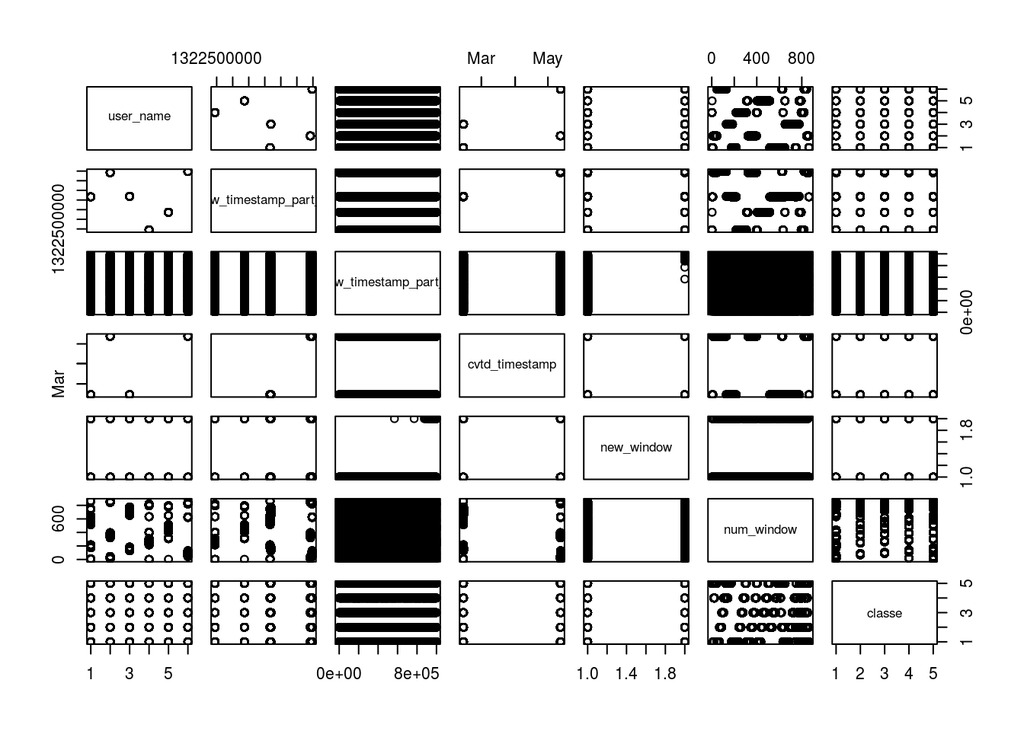

```r
small_pml <- subset( training,
                     select = c(user_name, raw_timestamp_part_1, raw_timestamp_part_2, cvtd_timestamp,
                                new_window, num_window, classe)
                     )
pairs( small_pml )
```

```r
training <- subset( training,
                    select = -c(user_name, raw_timestamp_part_1, raw_timestamp_part_2, cvtd_timestamp,
                                new_window, num_window) )
testing <- subset( testing,
                   select = -c(user_name, raw_timestamp_part_1, raw_timestamp_part_2, cvtd_timestamp,
                               new_window, num_window) )
```

We check that that there are no missing values in our training and testing sets:

```r
sum(is.na(training)); sum(is.na(testing))
```

```
## [1] 0
```

```
## [1] 0
```

Because there are no missing values, no imputing algorithm is needed and we proceed to building a machine learning model.

## Building a Machine Learning Algorithm

**1. Test Model - Decision Tree**

**2. Final Model - Random Forest**

We employ the random forest algorithm, *rf*, on our training and testing data sets. First, we train the model on our training set. We explore the dependence of the accuracy of the random forest algorithm on the number of trees grown, *ntree*. The resulting dependence is shown with open circles in the following plot. We also explore the dependence on the number of folds in the cross validation (*cv*) method. Open triangle, open circle and plus shape corresponds to the accuracy of the algorithm using $5$, $10$ and $15$ folds, respectively. We see that the accuracy using $5$ folds is lower, but increases with the choice of $10$ and $15$ folds; there is almost no difference between choosing $10$ or $15$ folds, the algorithm accuracy reaches about $99\%$ for $300$ trees, and we stick to the default $10$ fold method for the rest of our calculations.

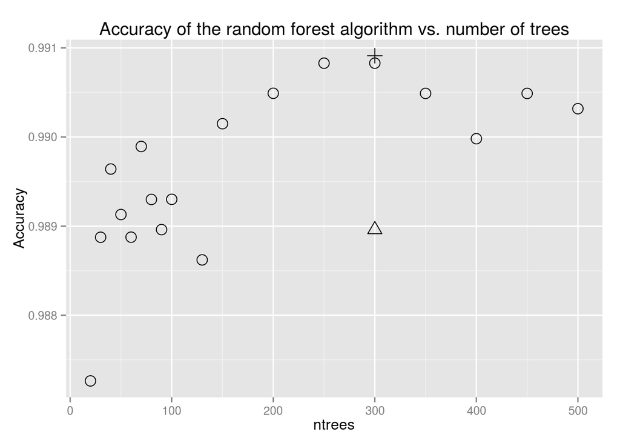

We run the random forest algorithm on our training data set (without any preprocessing). We choose $300$ trees, because this choice shows the largest accuracy of the algorithm; choosing a larger number of trees results in longer computational times and possibly in overfitting (the accuracy slightly decreases). We choose the train control method to be *cross validation*. The cross validation runs on our training set only. Internally, the training set is split into a new training and test set, the random forest model is built on the training set and evaluated on the test set; this process is then repeated and errors are averaged. The model is presented below. The out-of-bag (OOB) estimate of error rate is $0.95\%$ and the most important variable is *roll_belt*.

```r
ctrCV <- trainControl( method = "cv" )
modelFit_rf <- train( classe ~ . , method = "rf", data = training, prox = FALSE, ntree = 300, trControl = ctrCV )
modelFit_rf$finalModel
```

```
##
## Call:
##  randomForest(x = x, y = y, ntree = 300, mtry = param$mtry, proximity = FALSE)
##                Type of random forest: classification
##                      Number of trees: 300
## No. of variables tried at each split: 2
##
##         OOB estimate of  error rate: 0.95%
## Confusion matrix:
##      A    B    C    D    E class.error
## A 3343    3    1    0    1 0.001493429
## B   18 2251   10    0    0 0.012286090
## C    1   15 2033    5    0 0.010223953
## D    0    0   45 1882    3 0.024870466
## E    0    0    1    9 2155 0.004618938
```

```r
varImp( modelFit_rf )
```

```
## rf variable importance
##
##   only 20 most important variables shown (out of 52)
##
##                   Overall
## roll_belt          100.00
## yaw_belt            80.38
## magnet_dumbbell_z   67.37
## pitch_belt          63.60
## magnet_dumbbell_y   63.23
## pitch_forearm       60.79
## magnet_dumbbell_x   49.37
## roll_forearm        46.39
## accel_belt_z        45.12
## magnet_belt_z       43.52
## magnet_belt_y       42.96
## accel_dumbbell_y    42.27
## roll_dumbbell       37.83
## accel_dumbbell_z    35.26
## roll_arm            34.39
## accel_forearm_x     33.80
## gyros_belt_z        31.37
## yaw_dumbbell        29.80
## accel_dumbbell_x    29.77
## gyros_dumbbell_y    28.08
```

## Predictions and Out-of-Sample Error

We run our random forest model on the testing set. The predicted values of variable *classe* are stored in a new factor variable *predictions*. We create a confusion matrix where we compare our predictions with the actual classe values of the testing set.

```r
predictions <- predict( modelFit_rf, newdata = testing )
head( predictions )
```

```
## [1] A A A A A A
## Levels: A B C D E
```

```r
cM <- confusionMatrix( predictions, testing$classe )
cM
```

```
## Confusion Matrix and Statistics
##
##           Reference
## Prediction    A    B    C    D    E
##          A 2229   10    0    0    0
##          B    3 1502    8    0    0
##          C    0    6 1359   21    2
##          D    0    0    1 1263    3
##          E    0    0    0    2 1437
##
## Overall Statistics
##
##                Accuracy : 0.9929
##                  95% CI : (0.9907, 0.9946)
##     No Information Rate : 0.2845
##     P-Value [Acc > NIR] : < 2.2e-16
##
##                   Kappa : 0.991
##  Mcnemar's Test P-Value : NA
##
## Statistics by Class:
##
##                      Class: A Class: B Class: C Class: D Class: E
## Sensitivity            0.9987   0.9895   0.9934   0.9821   0.9965
## Specificity            0.9982   0.9983   0.9955   0.9994   0.9997
## Pos Pred Value         0.9955   0.9927   0.9791   0.9968   0.9986
## Neg Pred Value         0.9995   0.9975   0.9986   0.9965   0.9992
## Prevalence             0.2845   0.1935   0.1744   0.1639   0.1838
## Detection Rate         0.2841   0.1914   0.1732   0.1610   0.1832
## Detection Prevalence   0.2854   0.1928   0.1769   0.1615   0.1834
## Balanced Accuracy      0.9984   0.9939   0.9945   0.9908   0.9981
```

We find that the accuracy of our machine learning algorithm on the testing set is about 99.29$\%$. Both sensitivity and specificity of the model are more than $98\%$. The expected out of sample error is the proportion of missed predictions to the total number of observations in the test set and is equal to $1-Accuracy$, about 0.71$\%$. The out-of-bag (or out of sample) estimate based on the internal cross-validation during the run of the random forest algorithm is stated above and is about $0.95\%$. Notice that in random forests, there is no need for cross-validation or a separate test set to get an unbiased estimate of the test set error. It is estimated internally, during the run. (For more information, see *https://www.stat.berkeley.edu/~breiman/RandomForests/cc_home.htm#ooberr*.)

## Appendix

```r
summary(pmlDF[,setdiff(names(pmlDF), names(pmlDF_select))])
```

```
##        X         kurtosis_roll_belt kurtosis_picth_belt kurtosis_yaw_belt
##  Min.   :    1   Min.   :-2.121     Min.   :-2.190      Mode:logical
##  1st Qu.: 4906   1st Qu.:-1.329     1st Qu.:-1.107      NA's:19622
##  Median : 9812   Median :-0.899     Median :-0.151
##  Mean   : 9812   Mean   :-0.220     Mean   : 4.334
##  3rd Qu.:14717   3rd Qu.:-0.219     3rd Qu.: 3.178
##  Max.   :19622   Max.   :33.000     Max.   :58.000
##                  NA's   :19226      NA's   :19248
##  skewness_roll_belt skewness_roll_belt.1 skewness_yaw_belt
##  Min.   :-5.745     Min.   :-7.616       Mode:logical
##  1st Qu.:-0.444     1st Qu.:-1.114       NA's:19622
##  Median : 0.000     Median :-0.068
##  Mean   :-0.026     Mean   :-0.296
##  3rd Qu.: 0.417     3rd Qu.: 0.661
##  Max.   : 3.595     Max.   : 7.348
##  NA's   :19225      NA's   :19248
##  max_roll_belt     max_picth_belt   max_yaw_belt   min_roll_belt
##  Min.   :-94.300   Min.   : 3.00   Min.   :-2.10   Min.   :-180.00
##  1st Qu.:-88.000   1st Qu.: 5.00   1st Qu.:-1.30   1st Qu.: -88.40
##  Median : -5.100   Median :18.00   Median :-0.90   Median :  -7.85
##  Mean   : -6.667   Mean   :12.92   Mean   :-0.22   Mean   : -10.44
##  3rd Qu.: 18.500   3rd Qu.:19.00   3rd Qu.:-0.20   3rd Qu.:   9.05
##  Max.   :180.000   Max.   :30.00   Max.   :33.00   Max.   : 173.00
##  NA's   :19216     NA's   :19216   NA's   :19226   NA's   :19216
##  min_pitch_belt   min_yaw_belt   amplitude_roll_belt amplitude_pitch_belt
##  Min.   : 0.00   Min.   :-2.10   Min.   :  0.000     Min.   : 0.000
##  1st Qu.: 3.00   1st Qu.:-1.30   1st Qu.:  0.300     1st Qu.: 1.000
##  Median :16.00   Median :-0.90   Median :  1.000     Median : 1.000
##  Mean   :10.76   Mean   :-0.22   Mean   :  3.769     Mean   : 2.167
##  3rd Qu.:17.00   3rd Qu.:-0.20   3rd Qu.:  2.083     3rd Qu.: 2.000
##  Max.   :23.00   Max.   :33.00   Max.   :360.000     Max.   :12.000
##  NA's   :19216   NA's   :19226   NA's   :19216       NA's   :19216
##  amplitude_yaw_belt var_total_accel_belt avg_roll_belt    stddev_roll_belt
##  Min.   :0          Min.   : 0.000       Min.   :-27.40   Min.   : 0.000
##  1st Qu.:0          1st Qu.: 0.100       1st Qu.:  1.10   1st Qu.: 0.200
##  Median :0          Median : 0.200       Median :116.35   Median : 0.400
##  Mean   :0          Mean   : 0.926       Mean   : 68.06   Mean   : 1.337
##  3rd Qu.:0          3rd Qu.: 0.300       3rd Qu.:123.38   3rd Qu.: 0.700
##  Max.   :0          Max.   :16.500       Max.   :157.40   Max.   :14.200
##  NA's   :19226      NA's   :19216        NA's   :19216    NA's   :19216
```

[output cut: 177 more lines]

```
##  Min.   :-68.17    Min.   : 0.000       Min.   :   0.000
##  1st Qu.:  0.00    1st Qu.: 0.336       1st Qu.:   0.113
##  Median : 12.02    Median : 5.516       Median :  30.425
##  Mean   : 11.79    Mean   : 7.977       Mean   : 139.593
##  3rd Qu.: 28.48    3rd Qu.:12.866       3rd Qu.: 165.532
##  Max.   : 72.09    Max.   :47.745       Max.   :2279.617
##  NA's   :19216     NA's   :19216        NA's   :19216
##  avg_yaw_forearm   stddev_yaw_forearm var_yaw_forearm
##  Min.   :-155.06   Min.   :  0.000    Min.   :    0.00
##  1st Qu.: -26.26   1st Qu.:  0.524    1st Qu.:    0.27
##  Median :   0.00   Median : 24.743    Median :  612.21
##  Mean   :  18.00   Mean   : 44.854    Mean   : 4639.85
##  3rd Qu.:  85.79   3rd Qu.: 85.817    3rd Qu.: 7368.41
##  Max.   : 169.24   Max.   :197.508    Max.   :39009.33
##  NA's   :19216     NA's   :19216      NA's   :19216
```

**B. Correlations Between the Classe and Selected Non-Accelerator Variables**

```r
cor ( as.numeric(small_pml$classe), small_pml$raw_timestamp_part_1 )
```

```
## [1] 0.02107624
```

```r
cor ( as.numeric(small_pml$classe), small_pml$raw_timestamp_part_2 )
```

```
## [1] 0.02110493
```

```r
cor ( as.numeric(small_pml$classe), as.numeric(small_pml$new_window) )
```

```
## [1] 0.005669792
```

```r
cor ( as.numeric(small_pml$classe), as.numeric(small_pml$num_window) )
```

```
## [1] -0.01266311
```

**C. Test Model - Decision Tree**

**(i) Preprocessing with PCA**

```r
preProc_PCA <- preProcess( training[,-53], method = "pca" )
preProc_PCA
```

```
##
## Call:
## preProcess.default(x = training[, -53], method = "pca")
##
## Created from 11776 samples and 52 variables
## Pre-processing: principal component signal extraction, scaled, centered
##
## PCA needed 25 components to capture 95 percent of the variance
```

```r
train_PCA <- predict ( preProc_PCA, training[,-53] )
```

**(ii) Predictive Model**

```r
modelFit_rpart <- train( classe ~ . , method = "rpart", data = training )
modelFit_rpart
```

```
## CART
##
## 11776 samples
##    52 predictors
##     5 classes: 'A', 'B', 'C', 'D', 'E'
##
## No pre-processing
## Resampling: Bootstrapped (25 reps)
## Summary of sample sizes: 11776, 11776, 11776, 11776, 11776, 11776, ...
## Resampling results across tuning parameters:
##
##   cp          Accuracy   Kappa       Accuracy SD  Kappa SD
##   0.03909587  0.4977719  0.34989573  0.05517205   0.09118662
##   0.03946369  0.4977719  0.34989573  0.05517205   0.09118662
##   0.11449929  0.3282761  0.06918895  0.03930818   0.06264182
##
## Accuracy was used to select the optimal model using  the largest value.
## The final value used for the model was cp = 0.03946369.
```

```r
print( modelFit_rpart$finalModel )
```

```
## n= 11776
##
## node), split, n, loss, yval, (yprob)
##       * denotes terminal node
##
## 1) root 11776 8428 A (0.28 0.19 0.17 0.16 0.18)
##   2) roll_belt< 130.5 10799 7457 A (0.31 0.21 0.19 0.18 0.11) *
##   3) roll_belt>=130.5 977    6 E (0.0061 0 0 0 0.99) *
```

```r
modelFit_rpart_PCA <- train( training$classe ~ . , method = "rpart", data = train_PCA )
modelFit_rpart_PCA
```

[output not shown]

```r
print( modelFit_rpart_PCA$finalModel )
```

```
## n= 11776
##
## node), split, n, loss, yval, (yprob)
##       * denotes terminal node
##
## 1) root 11776 8428 A (0.28 0.19 0.17 0.16 0.18)
##   2) PC14>=-0.9010471 10595 7277 A (0.31 0.18 0.19 0.17 0.15)
##     4) PC8< 1.29235 8663 5593 A (0.35 0.17 0.22 0.11 0.14) *
##     5) PC8>=1.29235 1932 1157 D (0.13 0.24 0.065 0.4 0.17) *
##   3) PC14< -0.9010471 1181  568 E (0.025 0.28 0.03 0.14 0.52) *
```